# .center[What are FM and MZ B cells]

## B cell development in BM

Parallels between B and T cell development

Pro - Pre - selection and division - Immature B cells exit to periphery

???

End of the world post apocalyptic scenario you are an engineer and the fate of the world depends on how you make this one weapon that selectively neutralizes the aliens invading our planet

???

## B cell development in periphery

Immature B cells $\rightarrow$ B1 B cells and transitional B cells $\rightarrow$ FM and MZ B cells $\rightarrow$ GC and Memory

## Natural antibodies

poly clonal repertoire, TLR In combination with B1 B cells they produce natural antibody repertoire pre-made reservoir of antibodies

During the early phases of infection and before specific antibodies are produced, natural antibodies limit the dissemination of pathogens.

Natural antibodies are found in the serum of healthy individuals independently of previous immunizations, are mostly of IgM isotype and bind several antigens with low affinity

ready to fight

## Response against T-independent antigens

In general failure to elicit high-affinity antibody response by FO B cells.

B1 and MZ B cells identify these antigens – common molecular determinants conserved through evolution.

Low affinity antibodies that bind to multiple ligands. TLR and complement receptors.

Targets for innate response: IgM opsonizes the pathogens and enhances the innate immune response of macrophages

## Effcient and early response

rapid antigen presentation and shuttling between MZ and T cell zones rapid activation of T cell early response to pathogens that breach systemic barriers and emerge in blood before the high-affinity response from FM B cells takeover however, they are also capable of exhibiting a more classical B cell phenotype and differentiate into antibody-secreting cells and form germinal centers that lead to somatically mutated and class-switched memory cells

## Cell loss

### Death and onwards differentiation into memory and antibody producing cells.

## ### Depletion of repertoire

## ### Sustenance of ?diversity?

## Complexity & Dynamism in MZ B cell homeostasis:

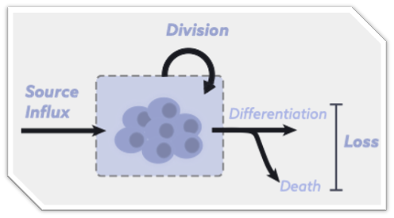

–

> Multiple processes regulate the numbers and diversity of naive T cells.

> Contribution of these processes to naive T cell maintenance may vary with time.

–

We are going to measure these processes. $\phi, \delta, \rho$.

.center[

### Understanding the development and maintenance of our T cell repertoires requires quantifying their ecology.

]

???

- In many ways it is an ecosystem - We need to quantify T cell ecology to understand the development and maintenance of our immune repertoires.

## MZ repertoire

–

- augmented by flow of new cells from the thymus → enhances diversity.

–

- sustained by proliferation (homeostatic self-renewal) →skews diversity

–

- depleted by loss of cells (by death and onward differentiation).

–

### 💡 Can we quantify all of these processes to understand how the repertoire is established and how it evolves over an individual’s lifespan?

## Big questions

### 1. How are MZ B cell maintained in adult mice?

busulfan – allows to measure replenishment and division

### 2. How is MZ B cell population is estabished in neonates?

Kinetics of development in early life $\rightarrow$ how newly made cells populate developing lymphoid niches?

Early life is a critical phase of immune development in which newly generated lymphocytes quickly populate and adapt to rapidly changing tissue environments.

Studying these dynamics early in life is important because they leave a strong imprint on lymphocyte subset numbers and diversity in the longer term.

Rag-gfp mice allows to study dynamics of recently exported cells and their division history.

### 3. What are their dynamics in an active immune response?

Modelling the dynamics of development, death and differentiation in animals that are immunized with T-dep antigen.

### Untangling division and loss:

- Previous studies estimated **Net Growth (division - loss)** rate of naive T cells.

### ⇒ Separating the effects of division and loss is crucial for studying lymphocyte dynamics.

  .right[ Verheijen & Rane *et. al.* Cell Reports 2020]

–

- $\small \text{Ki}67$ — a nuclear protein expressed during cell-division.  
  ↪ Independent handle on the rate of cell division.

.pull-left[

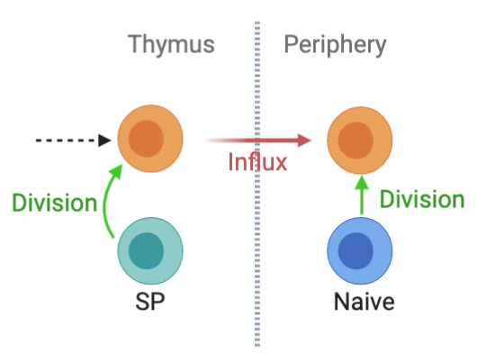

]

.pull-right[  
- T cells continue expressing Ki67 protein for ~ 4 days after the division. .right[ Hogan *et. al.*, PNAS 2015]

**Thymic Inheritance or division in periphery?** ]

–

.center[

### Modeling division-history is crucial for understanding how repertoires evolve.

]

??? We haven’t tried combination of one more processes - which may explain data better than the single model.